# Anomaly detection in time series

August 15, 2019

## Agenda

In this talk we will see:

- Outliers? What does it mean? .
- Outliers in time series and data to use.
- Plot and visualize anomalies in time series data.
- Explore different anomaly detection algorithms.
- How to deal with those outliers.

## Outliers in general

Outliers are extreme values that deviate from other observations on data.

Outliers are represented in two type:

- Ones with real occurence like fraudulent transaction in finance, people with an extremly high usage of data in telecom industry, income of client in millions and so one.
- Ones whome occured erroneously like client with 200 years old, failure detection of temprature that result high values.

Regardless, the presence of outliers needs to be understood and will require special treatment.

## univariate outliers

Some outliers may occur with in a single variable and can be detected using box plot as shown in plot 1 bellow.

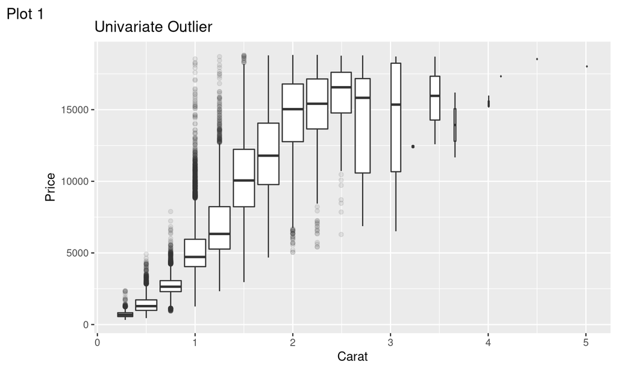

## Multivariate Outliers

And Others only occur if we combine mutlible variables, knowen as multivariate outliers as shown in plot 2.

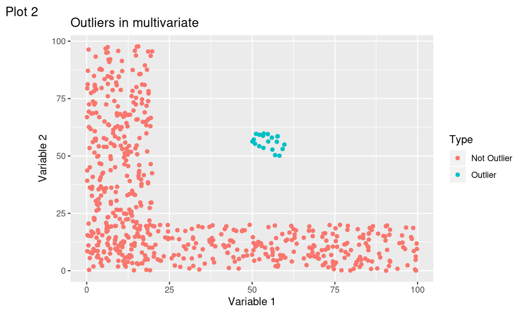

## Outliers in times series

In some field where time is an important dimension the conventional outlier detection won’t be applicable due to the impact of time so some methode are developped during past years to detect and deal with these outliers (AKA anomalies).

Some of these methodes are:  
- STL + IQR.  
- Twitter + GESD.  
- Sliding window-based forecasting method.  
- Exponential smoothing.

In our case will study outliers in google trend seach data for the word ‘Vote’ between 2004 and 2019 using GESD and STL in Anomalize package.

## Time series Data

Data selected using GtrendsR package.

```r
library(tidyverse)
library(gtrendsR)

GTrend_tbl <- gtrends(
  c('Vote'),
  gprop = 'web',
  geo=c('DZ'),
  time='2004-01-01 2019-07-29')[[1]] %>%
  mutate(date= seq.Date(as.Date('2004-01-29'),
                        as.Date('2019-08-01'),
                        by='month'))%>%
  tbl_df()
```

## Time series Data

[output not shown]

## Workflow of Anomaly detection

```r
library(anomalize)
GTrend_tbl %>%
  time_decompose(hits,
                 method = 'STL', # "stl", "twitter"
                 trend = '1 year') %>%

  anomalize(remainder,
            method='IQR' # "iqr", "gesd"
            )%>% # Step 2

  time_recompose() %>% #Step 3

  plot_anomalies(time_recomposed = TRUE) # Step 4
```

## Workflow of Anomaly detection

1- time_decompose

[output not shown]

## Workflow of Anomaly detection

2- anomalize

```
## # A tibble: 187 x 3
##    remainder_l1 remainder_l2 anomaly
##           <dbl>        <dbl> <chr>
##  1        -4.97         4.97 No
##  2        -4.97         4.97 Yes
##  3        -4.97         4.97 No
##  4        -4.97         4.97 Yes
##  5        -4.97         4.97 No
##  6        -4.97         4.97 No
##  7        -4.97         4.97 No
##  8        -4.97         4.97 No
##  9        -4.97         4.97 Yes
## 10        -4.97         4.97 Yes
## # … with 177 more rows
```

## Workflow of Anomaly detection

3- time_recompose

```
## # A tibble: 187 x 2
##    recomposed_l1 recomposed_l2
##            <dbl>         <dbl>
##  1         -4.91          5.02
##  2         -4.27          5.66
##  3         -3.36          6.57
##  4         -5.68          4.25
##  5         -4.92          5.01
##  6         -4.83          5.10
##  7         -5.55          4.38
##  8         -6.29          3.65
##  9         -5.49          4.44
## 10         -4.78          5.15
## # … with 177 more rows
```

## Workflow of Anomaly detection

4- plot_anomalies

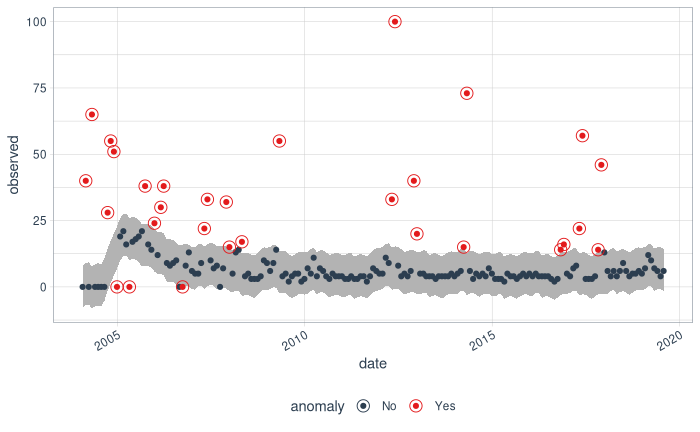

plot_anomalies

## Workflow of Anomaly detection

Plot Using Twitter + GESD method

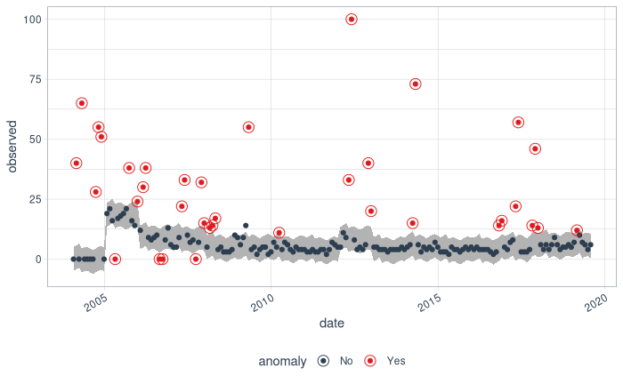

plot_anomalies

## Workflow of Anomaly detection

Difference between the two methodes above

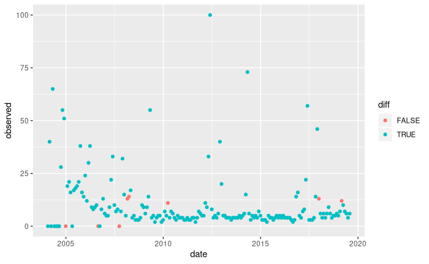

plot_anomalies

## Dealing with outliers:

What we need to know?

After Detecting outliers replacing theme is not always a solution, always it depends on our use case and our needs.

But in case we need to replace outlier for better prediction and removing noise there are some methodes:

1- Interpolation.

2- Kalman.

both of methodes above exist in imputeTS.

## Dealing with outliers:

Data from Step 3 is saved in test.rds file.

```r
library(imputeTS)
readRDS('test.rds') %>%
  mutate(observed = (ifelse(anomaly == 'Yes', NA, observed) %>%
                       na_kalman() %>%
                       as.integer()
                     )
         ) %>%
  ggplot( aes(x=date,y=observed,col=anomaly)) + geom_point()
```

If we need to use Interpolation instead we have just to chnage na_kalman() to na_interpolation().

## Dealing with outliers:

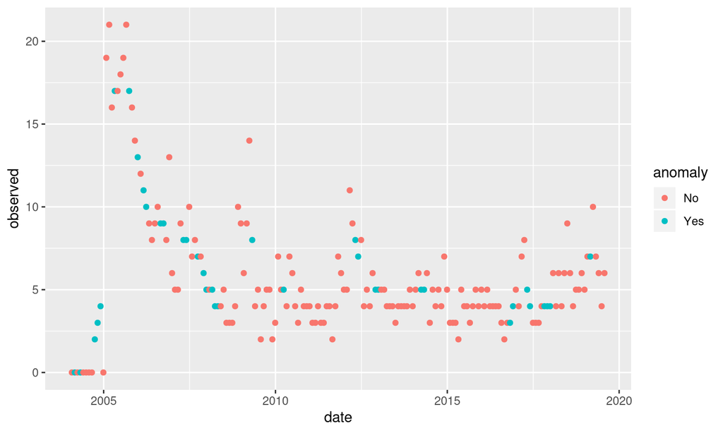